# Stat 218 - Analytics Paper 1

Donna Baret

March 3, 2019

# The paper is split into several parts namely

1. Data Management and or Preprocessing
2. Exploratory Analysis and Description of the Data
3. Discussing Model Strategy
4. Results and Discussion
5. Conclusion, model creation and Objective Fulfillment

# Data Management Procedures and Pre-Processing

Importing the data and setting categorical variables as factor for easier analysis.

```r
Movie_Gross_Income_and_Review <- read_csv("C:/Users/baretd/Desktop/STAT 218/Analytics Project 1/Movie Gross Income and Review.csv")
#Setting Factor Variables
Movie_Gross_Income_and_Review <- Movie_Gross_Income_and_Review %>% mutate(review=factor(Movie_Gross_Income_and_Review$review,ordered=F),
                            sequel=factor(Movie_Gross_Income_and_Review$sequel,ordered=F))
```

This paper tackles the different indicators that affects a movie’s income and overall review. The data is composed categorized into two:

## Conventional indicators are:

- Gross
- Review (Recommended or not)
- Budget
- Screens, and
- Sequel(If it’s a first movie or a sequel in a franchise) while the

## Online indicators are:

- Sentiment
- Views
- Likes
- Dislikes
- Comments and
- Followers

# Exploratory Data Analysis and Description

## Exploring which variables are affecting a Movie’s Gross Income and probability of having a Recommended review by majority of the critics, we plot it against different predictors.

### Determining relationship of gross to categorical variables Review and Sequel…

Based on the box plots below,gross income is noticeably higher for movies that are recommended by the majority of the critics but more widely distributed than not recommended. Moreover, there are more extremely high gross income value than normal for the non-recommended movies.Moreover, Gross income is higher for movies that are sequel but are more widely distributed. On the other hand, first movies has more extreme gross income yield.

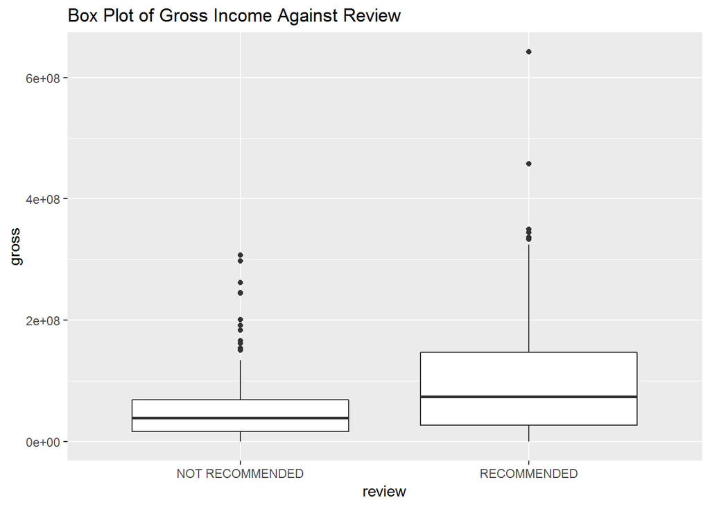

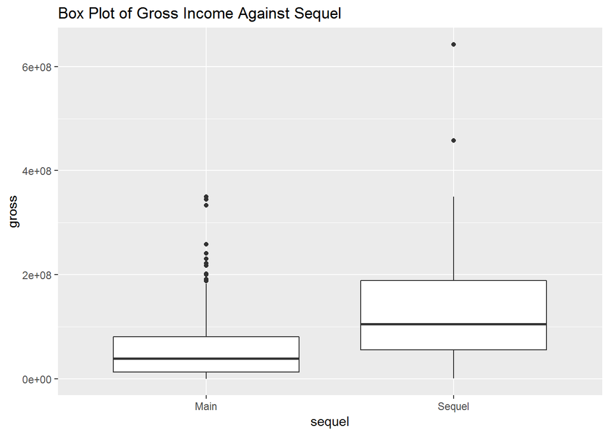

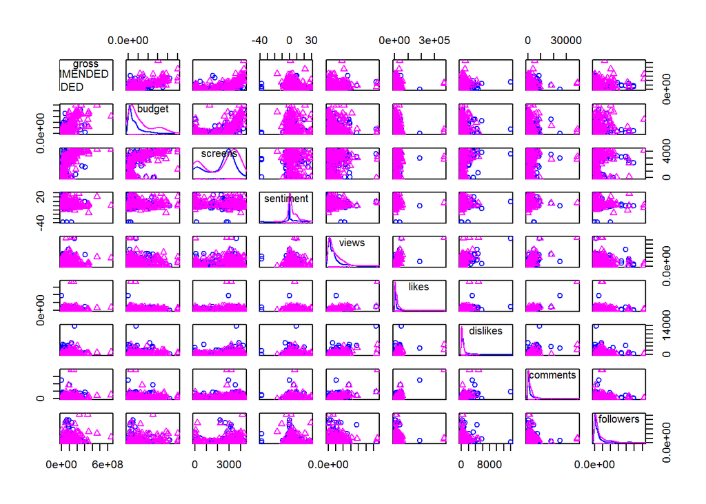

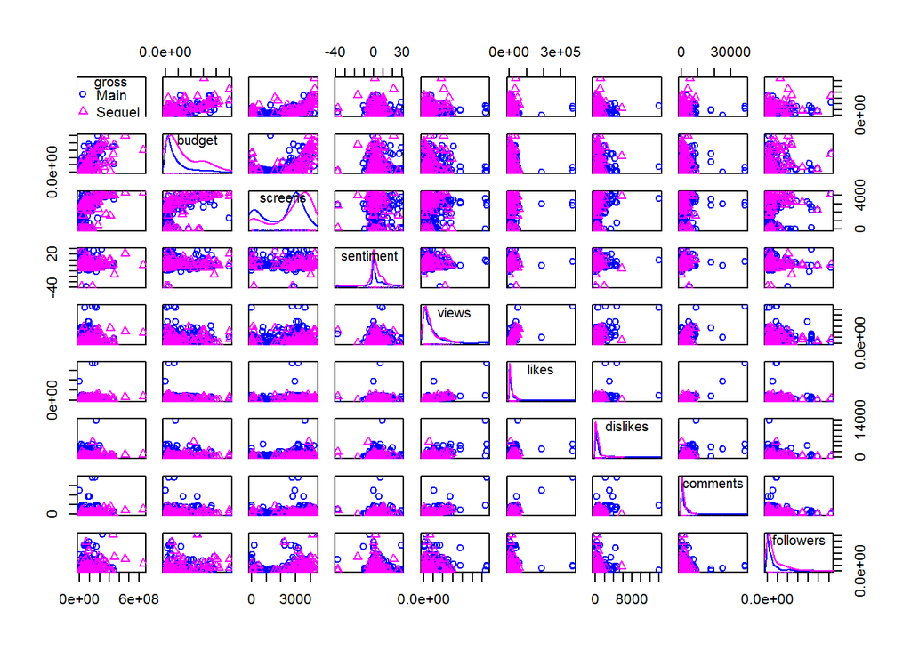

## Determining relationship of gross to quantitative variables

As we can see from the interaction of gross income to the quantitative variables,we can see that budget, screens, and followers have a visually linear positive correlation with gross income.

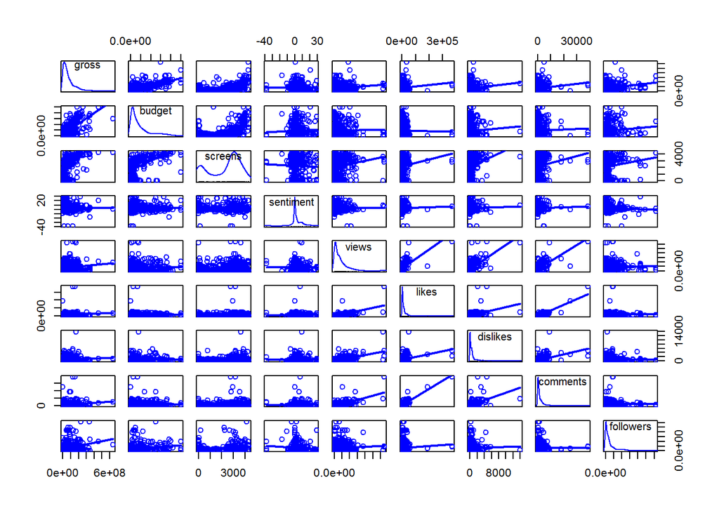

# Discussing Model Strategy

Variable selection in determining a Movie’s gross income and determining the probability of having a recommended outcome by majority of the critics is done by creating an initial model and running it through a step-wise selection procedure. Models are based on:

1. Full Model - Initial model is composed of conventional and online indicators
2. Conventional Indicators- Initial model is composed of conventional indicators
3. Online Indicators - Initial model is composed ofonline Indicators

With this, two models for determining a Movie’s gross income and determining the probability of having a recommended outcome by majority of the critics is generated. They are then compared if Generalized Additive Model (GAM) will create a model with better predicting capabilities. Moreover, we will choose the best model that will best explain the variability in a movie’s gross income and determining the probability of having a recommended outcome by majority of the critics. This is determined by using a 10-fold cross validation procedure and comparing with RMSE, R2, MAE for our continuous response model and Accuracy, Kappa for our categorical response model

## Fitting a Model for Gross Income

After running the three models and coming up with a model using step-wise model, we came up with the three and we assess it using residual error measures

```r
#Full Model
coefficients(glm.fit_full.select)
```

```
##       (Intercept)            budget      sequelSequel           screens
##     -2.061373e+07      6.888335e-01      5.102684e+07      1.339631e+04
## reviewRECOMMENDED         followers          comments
##      2.196441e+07      2.161097e+00      2.136689e+03
```

```r
#Non-Online Model
coefficients(glm.nononline.select)
```

```
##       (Intercept)            budget      sequelSequel           screens
##     -1.544187e+07      6.860316e-01      5.190519e+07      1.539883e+04
## reviewRECOMMENDED
##      2.418499e+07
```

```r
#Online Model
coefficients(glm.online.select)
```

```
##  (Intercept)    followers     comments
## 5.258015e+07 4.248909e+00 3.220921e+03
```

```r
errors <- sapply(list('all' = glm.fit_full.select,'non-online' =  glm.nononline.select, 'online' = glm.online.select) , fit_stats)
print(errors)
```

```
##              all   non-online       online
## MSE 2.291355e+15 2.455298e+15 5.689823e+15
## MAD 2.846311e+07 3.061826e+07 5.343766e+07
## AIC 1.510729e+04 1.513059e+04 1.545856e+04
## BIC 1.513912e+04 1.515446e+04 1.547447e+04
```

As we can see from the measures of residual errors, the model with all predictors and non-online predictors are the ones which has less MSE, MAD, AIC, and BIC. Therefore, we chose those two as our two models:

```r
#summary(glm.fit_full.select)
#summary(glm.nononline.select)
```

### Model 1 (Full Model) : Gross Income = -2.061e+07 + 6.888e-01 Budget + 5.103e+07 sequelSequel + 1.340e+04 Screens + 2.196e+07 reviewRECOMMENDED + 2.161e+00 Followers + 2.136689e+03 Comments

where reviewRECOMMENDED = 1 if recommended, 0 otherwise.

### Model 2 (Non Online) : Gross Income = -1.544187e+07 + 6.860316e-01 Budget + 5.190519e+07 sequelSequel + 1.539883e+04 Screens + 2.418499e+07 reviewRECOMMENDED

where reviewRECOMMENDED = 1 if recommended, 0 otherwise. sequelSequel = 1 if sequel, 0 otherwise.

## Fitting a Model for Determining the Probability of a Recommended Review

```r
#Full Model
coefficients(glm.review.select)
```

```
##   (Intercept)        budget  sequelSequel         gross       screens
## -7.112183e-01  1.896982e-08 -2.560385e+00  1.618117e-08 -6.137061e-04
##     sentiment      dislikes         likes      comments         views
##  7.444914e-02 -1.504285e-03  8.404400e-05 -3.571192e-04  1.749712e-07
```

```r
#Non-Online Model
coefficients(glm.nononline.review.select)
```

```
##   (Intercept)        budget  sequelSequel         gross       screens
## -2.519170e-01  1.229775e-08 -1.786033e+00  1.311648e-08 -4.696765e-04
```

```r
#Online Model
coefficients(glm.review.online.select)
```

```
##   (Intercept)     sentiment         likes      dislikes         views
## -5.302173e-01  5.405648e-02  5.060798e-05 -1.176432e-03  1.386903e-07
##      comments
## -1.525030e-04
```

```r
errorss <- sapply(list('all' = glm.review.select,'non-online' =  glm.nononline.review.select, 'online' = glm.review.online.select) , fit_stats)
print(errorss)
```

```
##            all non-online     online
## MSE  13.149743   5.522641   8.627537
## MAD   2.024505   1.987026   2.054364
## AIC 399.047145 471.875558 497.082257
## BIC 438.836003 491.769987 520.955571
```

Because of the significant difference, after stepwise selection of the MSE of the model where we used all variables, we choose the model that used ‘non-online’ and ‘online’ variables on the model

```r
#summary(glm.nononline.review.select)
#summary(glm.review.online.select)
```

### Model 2 (Online): logit(Review = Recommended) = -5.302e-01 + 5.406e-02 Sentiment + 5.061e-05 Likes - 1.176e-03 Dislikes + 1.387e-07 Views - 1.525e-04 Comments

## Comparison of Model vs GAM Model using Cross Validation

## For Gross Income

```r
sapply(list('GLM Model 1' = cv.glm1,'GAM Model 1' = cv.gam1,'GLM Model 2' =  cv.glm2, 'GAM Model 2' = cv.gam2) , cv_stats)
```

```
## $`GLM Model 1`
##         RMSE           R2          MAE
## 4.537366e+07 6.942077e-01 2.921646e+07
##
## $`GAM Model 1`
##        RMSE1        RMSE2          R21          R22         MAE1
## 4.570571e+07 4.530804e+07 6.626747e-01 6.627511e-01 2.933213e+07
##         MAE2
## 2.934215e+07
##
## $`GLM Model 2`
##         RMSE           R2          MAE
## 4.877487e+07 6.268756e-01 3.092912e+07
##
## $`GAM Model 2`
##        RMSE1        RMSE2          R21          R22         MAE1
## 4.770644e+07 4.754239e+07 6.472472e-01 6.487325e-01 3.064631e+07
##         MAE2
## 3.062948e+07
```

## For Review

```r
sapply(list('Review GLM Model 1' = cv.review.glm1,' Review GAM Model 1' = cv.review.gam1,'Review GLM Model 2' =  cv.review.glm2, 'Review Model 2' = cv.review.gam2) , cv_review)
```

```
## $`Review GLM Model 1`
##  Accuracy     Kappa
## 0.6662961 0.3125778
##
## $` Review GAM Model 1`
## Accuracy1 Accuracy2    Kappa1    Kappa2
## 0.6737179 0.6812179 0.3335571 0.3480316
##
## $`Review GLM Model 2`
##  Accuracy     Kappa
## 0.6429659 0.2660268
##
## $`Review Model 2`
## Accuracy1 Accuracy2    Kappa1    Kappa2
## 0.6813665 0.6890557 0.3510561 0.3683963
```

As we can see above,a GAM model resulted to a model with higher accuracy and a better Kappa coefficient for both the Models 1- Non-Online Predictors (Used budget, sequel, gross, screens) and Model 2- Online Predictors (sentiments, likes, dislikes, views, comments) that used only. This might be because of the flexibility of the GAM model.

# Results and Discussion

## Gross Income Prediction

Moreover, using cross validation, GAM transformed models with the same GLM predictors didn’t have a noticeable difference. Therefore, we use the model that used both the online and non-online predictors and went through the stepwise selection.

```r
summary(glm.fit_full.select)
```

```
##
## Call:
## glm(formula = gross ~ budget + sequel + screens + review + followers +
##     comments, data = Movie_Gross_Income_and_Review)
##
## Deviance Residuals:
##        Min          1Q      Median          3Q         Max
## -146723467   -20692986    -1968718    11632196   405773961
##
## Coefficients:
##                     Estimate Std. Error t value Pr(>|t|)
## (Intercept)       -2.061e+07  5.312e+06  -3.881 0.000122 ***
## budget             6.888e-01  5.963e-02  11.551  < 2e-16 ***
## sequelSequel       5.103e+07  6.513e+06   7.835 4.55e-14 ***
## screens            1.340e+04  2.150e+03   6.231 1.21e-09 ***
## reviewRECOMMENDED  2.196e+07  5.260e+06   4.176 3.67e-05 ***
## followers          2.161e+00  5.035e-01   4.292 2.24e-05 ***
## comments           2.137e+03  6.862e+02   3.114 0.001985 **
## ---
## Signif. codes:  0 '***' 0.001 '**' 0.01 '*' 0.05 '.' 0.1 ' ' 1
##
## (Dispersion parameter for gaussian family taken to be 2.332694e+15)
##
##     Null deviance: 2.4739e+18  on 394  degrees of freedom
## Residual deviance: 9.0509e+17  on 388  degrees of freedom
## AIC: 15107
##
## Number of Fisher Scoring iterations: 2
```

### Final Model for predicting gross income is:

#### Gross Income = -2.061e+07 + 6.888e-01 Budget + 5.103e+07 sequelSequel + 1.340e+04 Screens + 2.196e+07 reviewRECOMMENDED + 2.161e+00 Followers + 2.137e+03 Comments

We also saw that variables that includes both conventional and online indicators resulted to the best model based on both residual errors and cross validation results.Using the stepwise variable selection procedure, we choose budget, sequel, screens, review, followers, and comments as the best predictors on determining the variability on a movie’s gross income

Gross income increases as budget, screens, followers on social media, and comments on YouTube trailer increases, a movie is a sequel compared to the original, and a review is recommended compared to not by majority of the critics.

Given that there’s no budget allocated, the movie is not a sequel, there were no screens, the movie is not recommended and there are no followers and comments in social media, gross income in negative at $ 2.061e+07.

Holding other factors constant, we also see a 0.6888 dollar increase in gross income with a 1 dollar increase in budget

Holding other factors constant, we also see a 13400 dollar increase in gross income with a 1 screening increase in US during first two weeks of showing screens.

Holding other factors constant, we also see a 2.161 dollar increase in gross income with a 1 in the number of followers of main/primary movie actors in Facebook, Instagram, and twitter

Holding other factors constant, we also see a 2137 dollar increase in gross income with a 1 unit increase in number of comments of the trailer in YouTube

*Holding other factors constant, we also see a 51030000 dollar increase in gross income when a movie is a sequel in a franchise as compared to if it is the main movie

*Holding other factors constant, we also see a 21960000 dollar increase in gross income when a movie is recommended by the majority movie critics as compared to if it is not

## Probability of being Recommended by Majority of the Critics

Based on the result, between choosing the model with non-online vs online predictors, we choose the model with the least residual MSE (5.522641) and MAD (1.987026). (GLM Model 1) - logit(Review = Recommended) = -2.519170e-01 + 1.229775e-08 Budget + -1.786033e+00 Sequel + 1.311648e-08 Gross - -4.696765e-04 Screens.

It also resulted to a accuracy 66.63% accuracy and a minimal level of aggreement between the predicted and true review.

Moreover, using cross validation, GAM transformed models with the same GLM predictors yielded a better model

```r
summary(glm.nononline.review.select)
```

```
##
## Call:
## glm(formula = review ~ budget + sequel + gross + screens, family = binomial(link = "logit"),
##     data = Movie_Gross_Income_and_Review)
##
## Deviance Residuals:
##     Min       1Q   Median       3Q      Max
## -2.2694  -0.9729  -0.5048   1.1184   2.2371
##
## Coefficients:
##                Estimate Std. Error z value Pr(>|z|)
## (Intercept)  -2.519e-01  2.049e-01  -1.230 0.218802
## budget        1.230e-08  3.572e-09   3.443 0.000576 ***
## sequelSequel -1.786e+00  3.944e-01  -4.529 5.94e-06 ***
## gross         1.312e-08  2.935e-09   4.469 7.87e-06 ***
## screens      -4.697e-04  1.079e-04  -4.353 1.34e-05 ***
## ---
## Signif. codes:  0 '***' 0.001 '**' 0.01 '*' 0.05 '.' 0.1 ' ' 1
##
## (Dispersion parameter for binomial family taken to be 1)
##
##     Null deviance: 544.83  on 394  degrees of freedom
## Residual deviance: 461.88  on 390  degrees of freedom
## AIC: 471.88
##
## Number of Fisher Scoring iterations: 5
```

```r
# fitreview.gam2 <- gam::gam(review ~ sentiment + likes + dislikes + views + comments, family=binomial(link = 'logit'), data=Movie_Gross_Income_and_Review)
#
# summary(fitreview.gam2)
```

### Final Model for Predicting the Probability of having a ‘Recommended’ Review remark

#### logit(Review = Recommended) = -2.519170e-01 + 1.229775e-08 Budget + -1.786033e+00 Sequel + 1.311648e-08 Gross - -4.696765e-04 Screens

The odds of a movie being recommended by the majority movie critics as compared to if it is not, increases by 1when budget increases by 1 dollar holding everything at a fixed value

The odds of a movie being recommended by the majority movie critics as compared to if it is not, increases by 1  
when gross income increase by 1 dollar holding everything at a fixed value

The odds of a movie being recommended by the majority movie critics as compared to if it is not, increases by 0.1676293 if the movie is a sequel as compared if it is holding everything at a fixed value.

# Conclusion, Model Creation and Objective Fulfillment

Using GLM, we have have developed these two models for determinining a movie’s gross income and explaining the probability of having a “recommended” remark.

As a preliminary analysis, we have devided the predictors into two categories, conventional indicators, and online indicators. We then created 3 initial models composing of both ‘conventional indicators and online indicators’, conventional indicators only, and online indicators only. After this, we ran each model through a Stepwise Selection Procedure to determine which of those variables are significant for our model.

In determining which of the 3 models we’ll choose, we compare their MSE, MAD, AIC, and BIC and choose a model with the least value.

After selecting the top 2 models, we also cross validated it using a 10-fold cross validation procedure and ran their equivalent GAM models. We’ve compared the effectivenes of the model using RMSE, R2, MAE for continuous variables, and Accruacy and Kappa Coefficient for categorical variable

##For gross income, we have generated these two models

```
    ### Model 1 (Full Model) : Gross Income = -2.061e+07 + 6.888e-01 Budget + 5.103e+07 sequelSequel + 1.340e+04 Screens + 2.196e+07 reviewRECOMMENDED + 2.161e+00 Followers + 2.136689e+03 Comments

      where reviewRECOMMENDED = 1 if recommended, 0 otherwise.

    ### Model 2 (Non Online) : Gross Income = -1.544187e+07 + 6.860316e-01 Budget + 5.190519e+07 sequelSequel + 1.539883e+04 Screens + 2.418499e+07 reviewRECOMMENDED

      where reviewRECOMMENDED = 1 if recommended, 0 otherwise. sequelSequel = 1 if sequel, 0 otherwise.
```

We’ve seen that variables that has both ‘online and non-online’ predictors and non-online predictors did a better job at determining a movie’s gross income. Moreover, model which has both the ‘online and non-online’ did the best job on doing so. We have seen that there’s a big increase in gross income if a movie is a sequel compared to if it’s the first movie and if it’s recommended by majority of the critics compared to if it’s not holding other factors constant. Moreover, gross income increases by almost 69% of the budget dedicated holding other factor constant.

##For Explaining the probability of having a “Recommended” remark

[output not shown]

In determing the probability of having a ‘Recommended’ remark, we have seen that a solely ‘Non-Online’ and a solely ‘Online’ predictor model performed better than the full one. Moreover, a model with the non-online predictors did the best performance in the case of residual errors. Model 1(Non-online) had an accuracy 66.63% accuracy and a minimal level of aggreement between the predicted and true review.

The model also tells us that holding each of the rest of the variables constant, odd of it having a recommended review increases by one for 1 dollar increase in budget, and for 1 for income.

A GAM model equivalent resulted to better cross validation error results.

In general, the combination of both conventional and online variables resulted to the best model in determining a movie’s gross income. On the other hand, non-online variables resulted to the best model in determining the probability of a recommended review.

Moreover, if we’d want to determine if a movie’s successful, a better metric is to use a movie’s net income instead of gross. It is also recommended to explore interaction effects of the variables.